# Risk Factor Analysis

## Outcome Variable

**Outcome Variable:** haz

## Predictor Variables

**Intervention Variable:** mbmi

**Adjustment Set:**

- arm
- W_mage
- W_fage
- meducyrs
- feducyrs
- single
- brthmon
- W_gagebrth
- W_birthwt
- W_birthlen
- vagbrth
- delta_W_mage
- delta_W_fage
- delta_meducyrs
- delta_feducyrs
- delta_single
- delta_brthmon
- delta_W_gagebrth
- delta_W_birthwt
- delta_W_birthlen
- delta_vagbrth

## Stratifying Variables

The analysis was stratified on these variable(s):

- agecat
- studyid
- country

## Data Summary

| agecat | studyid | country | mbmi | n_cell | n |
| --- | --- | --- | --- | --- | --- |
| 6 months | ki0047075b-MAL-ED | BANGLADESH | Normal weight | 209 | 241 |
| 6 months | ki0047075b-MAL-ED | BANGLADESH | Underweight | 32 | 241 |
| 6 months | ki0047075b-MAL-ED | BRAZIL | Normal weight | 199 | 208 |
| 6 months | ki0047075b-MAL-ED | BRAZIL | Underweight | 9 | 208 |
| 6 months | ki0047075b-MAL-ED | INDIA | Normal weight | 186 | 235 |
| 6 months | ki0047075b-MAL-ED | INDIA | Underweight | 49 | 235 |
| 6 months | ki0047075b-MAL-ED | NEPAL | Normal weight | 236 | 236 |
| 6 months | ki0047075b-MAL-ED | NEPAL | Underweight | 0 | 236 |
| 6 months | ki0047075b-MAL-ED | PERU | Normal weight | 267 | 272 |
| 6 months | ki0047075b-MAL-ED | PERU | Underweight | 5 | 272 |
| 6 months | ki0047075b-MAL-ED | SOUTH AFRICA | Normal weight | 242 | 249 |
| 6 months | ki0047075b-MAL-ED | SOUTH AFRICA | Underweight | 7 | 249 |
| 6 months | ki0047075b-MAL-ED | TANZANIA, UNITED REPUBLIC OF | Normal weight | 233 | 247 |
| 6 months | ki0047075b-MAL-ED | TANZANIA, UNITED REPUBLIC OF | Underweight | 14 | 247 |
| 6 months | ki1000304b-SAS-CompFeed | INDIA | Normal weight | 922 | 1227 |
| 6 months | ki1000304b-SAS-CompFeed | INDIA | Underweight | 305 | 1227 |
| 6 months | ki1017093-NIH-Birth | BANGLADESH | Normal weight | 444 | 537 |
| 6 months | ki1017093-NIH-Birth | BANGLADESH | Underweight | 93 | 537 |
| 6 months | ki1017093b-PROVIDE | BANGLADESH | Normal weight | 481 | 582 |
| 6 months | ki1017093b-PROVIDE | BANGLADESH | Underweight | 101 | 582 |
| 6 months | ki1017093c-NIH-Crypto | BANGLADESH | Normal weight | 648 | 715 |
| 6 months | ki1017093c-NIH-Crypto | BANGLADESH | Underweight | 67 | 715 |
| 6 months | ki1066203-TanzaniaChild2 | TANZANIA, UNITED REPUBLIC OF | Normal weight | 1949 | 1983 |
| 6 months | ki1066203-TanzaniaChild2 | TANZANIA, UNITED REPUBLIC OF | Underweight | 34 | 1983 |
| 6 months | ki1119695-PROBIT | BELARUS | Normal weight | 12522 | 13027 |
| 6 months | ki1119695-PROBIT | BELARUS | Underweight | 505 | 13027 |
| 6 months | ki1126311-ZVITAMBO | ZIMBABWE | Normal weight | 6747 | 7109 |
| 6 months | ki1126311-ZVITAMBO | ZIMBABWE | Underweight | 362 | 7109 |
| 6 months | ki1148112-LCNI-5 | MALAWI | Normal weight | 691 | 836 |
| 6 months | ki1148112-LCNI-5 | MALAWI | Underweight | 145 | 836 |
| 24 months | ki0047075b-MAL-ED | BANGLADESH | Normal weight | 183 | 212 |
| 24 months | ki0047075b-MAL-ED | BANGLADESH | Underweight | 29 | 212 |
| 24 months | ki0047075b-MAL-ED | BRAZIL | Normal weight | 162 | 168 |
| 24 months | ki0047075b-MAL-ED | BRAZIL | Underweight | 6 | 168 |
| 24 months | ki0047075b-MAL-ED | INDIA | Normal weight | 180 | 226 |
| 24 months | ki0047075b-MAL-ED | INDIA | Underweight | 46 | 226 |
| 24 months | ki0047075b-MAL-ED | NEPAL | Normal weight | 228 | 228 |
| 24 months | ki0047075b-MAL-ED | NEPAL | Underweight | 0 | 228 |
| 24 months | ki0047075b-MAL-ED | PERU | Normal weight | 197 | 201 |
| 24 months | ki0047075b-MAL-ED | PERU | Underweight | 4 | 201 |
| 24 months | ki0047075b-MAL-ED | SOUTH AFRICA | Normal weight | 227 | 234 |
| 24 months | ki0047075b-MAL-ED | SOUTH AFRICA | Underweight | 7 | 234 |
| 24 months | ki0047075b-MAL-ED | TANZANIA, UNITED REPUBLIC OF | Normal weight | 203 | 214 |
| 24 months | ki0047075b-MAL-ED | TANZANIA, UNITED REPUBLIC OF | Underweight | 11 | 214 |
| 24 months | ki1017093-NIH-Birth | BANGLADESH | Normal weight | 349 | 429 |
| 24 months | ki1017093-NIH-Birth | BANGLADESH | Underweight | 80 | 429 |
| 24 months | ki1017093b-PROVIDE | BANGLADESH | Normal weight | 476 | 576 |
| 24 months | ki1017093b-PROVIDE | BANGLADESH | Underweight | 100 | 576 |
| 24 months | ki1017093c-NIH-Crypto | BANGLADESH | Normal weight | 471 | 514 |
| 24 months | ki1017093c-NIH-Crypto | BANGLADESH | Underweight | 43 | 514 |
| 24 months | ki1066203-TanzaniaChild2 | TANZANIA, UNITED REPUBLIC OF | Normal weight | 6 | 6 |
| 24 months | ki1066203-TanzaniaChild2 | TANZANIA, UNITED REPUBLIC OF | Underweight | 0 | 6 |
| 24 months | ki1119695-PROBIT | BELARUS | Normal weight | 3863 | 4005 |
| 24 months | ki1119695-PROBIT | BELARUS | Underweight | 142 | 4005 |
| 24 months | ki1126311-ZVITAMBO | ZIMBABWE | Normal weight | 352 | 377 |
| 24 months | ki1126311-ZVITAMBO | ZIMBABWE | Underweight | 25 | 377 |
| 24 months | ki1148112-LCNI-5 | MALAWI | Normal weight | 482 | 577 |
| 24 months | ki1148112-LCNI-5 | MALAWI | Underweight | 95 | 577 |

The following strata were considered:

- agecat: 24 months, studyid: ki0047075b-MAL-ED, country: BANGLADESH
- agecat: 24 months, studyid: ki0047075b-MAL-ED, country: BRAZIL
- agecat: 24 months, studyid: ki0047075b-MAL-ED, country: INDIA
- agecat: 24 months, studyid: ki0047075b-MAL-ED, country: NEPAL
- agecat: 24 months, studyid: ki0047075b-MAL-ED, country: PERU
- agecat: 24 months, studyid: ki0047075b-MAL-ED, country: SOUTH AFRICA
- agecat: 24 months, studyid: ki0047075b-MAL-ED, country: TANZANIA, UNITED REPUBLIC OF
- agecat: 24 months, studyid: ki1017093-NIH-Birth, country: BANGLADESH
- agecat: 24 months, studyid: ki1017093b-PROVIDE, country: BANGLADESH
- agecat: 24 months, studyid: ki1017093c-NIH-Crypto, country: BANGLADESH
- agecat: 24 months, studyid: ki1066203-TanzaniaChild2, country: TANZANIA, UNITED REPUBLIC OF
- agecat: 24 months, studyid: ki1119695-PROBIT, country: BELARUS
- agecat: 24 months, studyid: ki1126311-ZVITAMBO, country: ZIMBABWE
- agecat: 24 months, studyid: ki1148112-LCNI-5, country: MALAWI
- agecat: 6 months, studyid: ki0047075b-MAL-ED, country: BANGLADESH
- agecat: 6 months, studyid: ki0047075b-MAL-ED, country: BRAZIL
- agecat: 6 months, studyid: ki0047075b-MAL-ED, country: INDIA
- agecat: 6 months, studyid: ki0047075b-MAL-ED, country: NEPAL
- agecat: 6 months, studyid: ki0047075b-MAL-ED, country: PERU
- agecat: 6 months, studyid: ki0047075b-MAL-ED, country: SOUTH AFRICA
- agecat: 6 months, studyid: ki0047075b-MAL-ED, country: TANZANIA, UNITED REPUBLIC OF
- agecat: 6 months, studyid: ki1000304b-SAS-CompFeed, country: INDIA
- agecat: 6 months, studyid: ki1017093-NIH-Birth, country: BANGLADESH
- agecat: 6 months, studyid: ki1017093b-PROVIDE, country: BANGLADESH
- agecat: 6 months, studyid: ki1017093c-NIH-Crypto, country: BANGLADESH
- agecat: 6 months, studyid: ki1066203-TanzaniaChild2, country: TANZANIA, UNITED REPUBLIC OF
- agecat: 6 months, studyid: ki1119695-PROBIT, country: BELARUS
- agecat: 6 months, studyid: ki1126311-ZVITAMBO, country: ZIMBABWE
- agecat: 6 months, studyid: ki1148112-LCNI-5, country: MALAWI

### Dropped Strata

Some strata were dropped due to rare outcomes:

- agecat: 6 months, studyid: ki0047075b-MAL-ED, country: NEPAL
- agecat: 24 months, studyid: ki0047075b-MAL-ED, country: NEPAL
- agecat: 24 months, studyid: ki0047075b-MAL-ED, country: PERU
- agecat: 24 months, studyid: ki1066203-TanzaniaChild2, country: TANZANIA, UNITED REPUBLIC OF

## Methods Detail

We’re interested in the causal parameters $E[Y_a]$ for all values of $a \in \mathcal{A}$. These parameters represent the mean outcome if, possibly contrary to fact, we intervened to set all units to have $A=a$. Under the randomization and positivity assumptions, these are identified by the statistical parameters $\psi_a=E_W[E_{Y|A,W}(Y|A=a,W)]$. In addition, we’re interested in the mean of $Y$, $E[Y]$ under no intervention (the observed mean). We will estimate these parameters by using SuperLearner to fit the relevant likelihood factors – $E_{Y|A,W}(Y|A=a,W)$ and $p(A=a|W)$, and then updating our likelihood fit using a joint TMLE.

For unadjusted analyses ($W=\{\}$), initial likelihoods were estimated using Lrnr_glm to estimate the simple $E(Y|A)$ and Lrnr_mean to estimate $p(A)$. For adjusted analyses, a small library containing Lrnr_glmnet, Lrnr_xgboost, and Lrnr_mean was used.

# Results Detail

## Results Plots

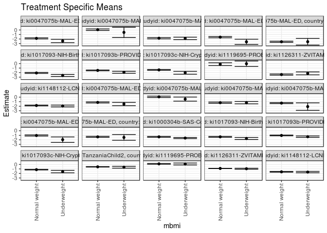

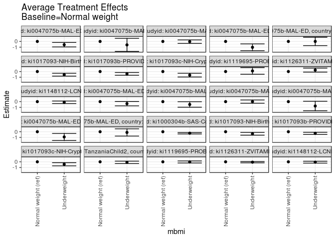

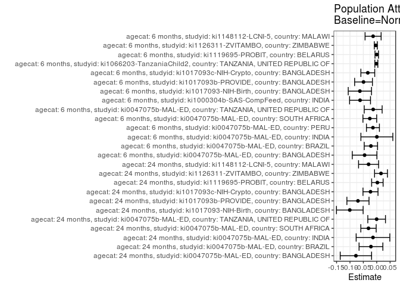

## Results Table

### Parameter: TSM

| agecat | studyid | country | intervention_level | baseline_level | estimate | ci_lower | ci_upper |
| --- | --- | --- | --- | --- | --- | --- | --- |
| 6 months | ki0047075b-MAL-ED | BANGLADESH | Normal weight | NA | -1.1603590 | -1.2853756 | -1.0353424 |
| 6 months | ki0047075b-MAL-ED | BANGLADESH | Underweight | NA | -1.5143731 | -1.8790037 | -1.1497425 |
| 6 months | ki0047075b-MAL-ED | BRAZIL | Normal weight | NA | 0.0748995 | -0.0742030 | 0.2240020 |
| 6 months | ki0047075b-MAL-ED | BRAZIL | Underweight | NA | -0.4262963 | -0.8810079 | 0.0284153 |
| 6 months | ki0047075b-MAL-ED | INDIA | Normal weight | NA | -1.2154082 | -1.3473834 | -1.0834331 |
| 6 months | ki0047075b-MAL-ED | INDIA | Underweight | NA | -1.2129646 | -1.4706138 | -0.9553154 |
| 6 months | ki0047075b-MAL-ED | PERU | Normal weight | NA | -1.3131149 | -1.4218494 | -1.2043803 |
| 6 months | ki0047075b-MAL-ED | PERU | Underweight | NA | -2.0820000 | -2.9100519 | -1.2539481 |
| 6 months | ki0047075b-MAL-ED | SOUTH AFRICA | Normal weight | NA | -1.0469731 | -1.1780219 | -0.9159244 |
| 6 months | ki0047075b-MAL-ED | SOUTH AFRICA | Underweight | NA | -1.9657143 | -2.5717876 | -1.3596410 |
| 6 months | ki0047075b-MAL-ED | TANZANIA, UNITED REPUBLIC OF | Normal weight | NA | -1.3469467 | -1.4709243 | -1.2229692 |
| 6 months | ki0047075b-MAL-ED | TANZANIA, UNITED REPUBLIC OF | Underweight | NA | -1.4729175 | -2.1001070 | -0.8457280 |
| 6 months | ki1000304b-SAS-CompFeed | INDIA | Normal weight | NA | -1.3449333 | -1.4429227 | -1.2469439 |
| 6 months | ki1000304b-SAS-CompFeed | INDIA | Underweight | NA | -1.6092659 | -1.7247064 | -1.4938253 |
| 6 months | ki1017093-NIH-Birth | BANGLADESH | Normal weight | NA | -1.3444287 | -1.4395909 | -1.2492664 |
| 6 months | ki1017093-NIH-Birth | BANGLADESH | Underweight | NA | -1.7067810 | -1.9300894 | -1.4834726 |
| 6 months | ki1017093b-PROVIDE | BANGLADESH | Normal weight | NA | -1.0355360 | -1.1206479 | -0.9504241 |
| 6 months | ki1017093b-PROVIDE | BANGLADESH | Underweight | NA | -1.3159637 | -1.4815859 | -1.1503415 |
| 6 months | ki1017093c-NIH-Crypto | BANGLADESH | Normal weight | NA | -1.1653715 | -1.2393729 | -1.0913702 |
| 6 months | ki1017093c-NIH-Crypto | BANGLADESH | Underweight | NA | -1.5946323 | -1.8642908 | -1.3249738 |
| 6 months | ki1066203-TanzaniaChild2 | TANZANIA, UNITED REPUBLIC OF | Normal weight | NA | -0.5392018 | -0.5895276 | -0.4888761 |
| 6 months | ki1066203-TanzaniaChild2 | TANZANIA, UNITED REPUBLIC OF | Underweight | NA | -0.6288772 | -0.8357535 | -0.4220009 |
| 6 months | ki1119695-PROBIT | BELARUS | Normal weight | NA | 0.1152564 | 0.0225551 | 0.2079577 |
| 6 months | ki1119695-PROBIT | BELARUS | Underweight | NA | 0.0871434 | -0.1244680 | 0.2987549 |
| 6 months | ki1126311-ZVITAMBO | ZIMBABWE | Normal weight | NA | -0.8975527 | -0.9259350 | -0.8691704 |
| 6 months | ki1126311-ZVITAMBO | ZIMBABWE | Underweight | NA | -0.9607213 | -1.0726547 | -0.8487880 |
| 6 months | ki1148112-LCNI-5 | MALAWI | Normal weight | NA | -1.6442430 | -1.7222910 | -1.5661951 |
| 6 months | ki1148112-LCNI-5 | MALAWI | Underweight | NA | -1.7009845 | -1.8512834 | -1.5506856 |
| 24 months | ki0047075b-MAL-ED | BANGLADESH | Normal weight | NA | -1.8653431 | -1.9958409 | -1.7348452 |
| 24 months | ki0047075b-MAL-ED | BANGLADESH | Underweight | NA | -2.4381916 | -2.8116395 | -2.0647437 |
| 24 months | ki0047075b-MAL-ED | BRAZIL | Normal weight | NA | 0.0633642 | -0.1049962 | 0.2317246 |
| 24 months | ki0047075b-MAL-ED | BRAZIL | Underweight | NA | -0.5391667 | -1.6773310 | 0.5989977 |
| 24 months | ki0047075b-MAL-ED | INDIA | Normal weight | NA | -1.8300096 | -1.9719744 | -1.6880449 |
| 24 months | ki0047075b-MAL-ED | INDIA | Underweight | NA | -1.8648941 | -2.1378093 | -1.5919790 |
| 24 months | ki0047075b-MAL-ED | SOUTH AFRICA | Normal weight | NA | -1.5912775 | -1.7294629 | -1.4530921 |
| 24 months | ki0047075b-MAL-ED | SOUTH AFRICA | Underweight | NA | -2.6192857 | -3.1998173 | -2.0387542 |
| 24 months | ki0047075b-MAL-ED | TANZANIA, UNITED REPUBLIC OF | Normal weight | NA | -2.6056088 | -2.7429392 | -2.4682784 |
| 24 months | ki0047075b-MAL-ED | TANZANIA, UNITED REPUBLIC OF | Underweight | NA | -2.6002419 | -3.3263053 | -1.8741784 |
| 24 months | ki1017093-NIH-Birth | BANGLADESH | Normal weight | NA | -2.0801618 | -2.1938597 | -1.9664640 |
| 24 months | ki1017093-NIH-Birth | BANGLADESH | Underweight | NA | -2.6320952 | -2.8572097 | -2.4069807 |
| 24 months | ki1017093b-PROVIDE | BANGLADESH | Normal weight | NA | -1.5137774 | -1.6040002 | -1.4235546 |
| 24 months | ki1017093b-PROVIDE | BANGLADESH | Underweight | NA | -1.9234876 | -2.1532692 | -1.6937060 |
| 24 months | ki1017093c-NIH-Crypto | BANGLADESH | Normal weight | NA | -1.4062737 | -1.4926439 | -1.3199036 |
| 24 months | ki1017093c-NIH-Crypto | BANGLADESH | Underweight | NA | -2.0335465 | -2.3474227 | -1.7196702 |
| 24 months | ki1119695-PROBIT | BELARUS | Normal weight | NA | -0.1347171 | -0.4407273 | 0.1712932 |
| 24 months | ki1119695-PROBIT | BELARUS | Underweight | NA | -0.0276122 | -0.6245632 | 0.5693387 |
| 24 months | ki1126311-ZVITAMBO | ZIMBABWE | Normal weight | NA | -2.4295680 | -2.5590258 | -2.3001101 |
| 24 months | ki1126311-ZVITAMBO | ZIMBABWE | Underweight | NA | -2.1706408 | -2.4977231 | -1.8435584 |
| 24 months | ki1148112-LCNI-5 | MALAWI | Normal weight | NA | -1.8440383 | -1.9334782 | -1.7545985 |
| 24 months | ki1148112-LCNI-5 | MALAWI | Underweight | NA | -1.9579676 | -2.1619471 | -1.7539881 |

### Parameter: E(Y)

| agecat | studyid | country | intervention_level | baseline_level | estimate | ci_lower | ci_upper |
| --- | --- | --- | --- | --- | --- | --- | --- |
| 6 months | ki0047075b-MAL-ED | BANGLADESH | NA | NA | -1.2056777 | -1.3231497 | -1.0882058 |
| 6 months | ki0047075b-MAL-ED | BRAZIL | NA | NA | 0.0532131 | -0.0914567 | 0.1978830 |
| 6 months | ki0047075b-MAL-ED | INDIA | NA | NA | -1.2148369 | -1.3332371 | -1.0964367 |
| 6 months | ki0047075b-MAL-ED | PERU | NA | NA | -1.3272488 | -1.4359649 | -1.2185326 |
| 6 months | ki0047075b-MAL-ED | SOUTH AFRICA | NA | NA | -1.0728012 | -1.2026830 | -0.9429194 |
| 6 months | ki0047075b-MAL-ED | TANZANIA, UNITED REPUBLIC OF | NA | NA | -1.3601215 | -1.4821830 | -1.2380600 |
| 6 months | ki1000304b-SAS-CompFeed | INDIA | NA | NA | -1.4072209 | -1.4983514 | -1.3160903 |
| 6 months | ki1017093-NIH-Birth | BANGLADESH | NA | NA | -1.4073821 | -1.4960598 | -1.3187043 |
| 6 months | ki1017093b-PROVIDE | BANGLADESH | NA | NA | -1.0848568 | -1.1613109 | -1.0084028 |
| 6 months | ki1017093c-NIH-Crypto | BANGLADESH | NA | NA | -1.1986783 | -1.2700937 | -1.1272630 |
| 6 months | ki1066203-TanzaniaChild2 | TANZANIA, UNITED REPUBLIC OF | NA | NA | -0.5405711 | -0.5899965 | -0.4911457 |
| 6 months | ki1119695-PROBIT | BELARUS | NA | NA | 0.1153731 | 0.0222128 | 0.2085334 |
| 6 months | ki1126311-ZVITAMBO | ZIMBABWE | NA | NA | -0.9008757 | -0.9285733 | -0.8731780 |
| 6 months | ki1148112-LCNI-5 | MALAWI | NA | NA | -1.6577751 | -1.7275296 | -1.5880207 |
| 24 months | ki0047075b-MAL-ED | BANGLADESH | NA | NA | -1.9431132 | -2.0691678 | -1.8170586 |
| 24 months | ki0047075b-MAL-ED | BRAZIL | NA | NA | 0.0418452 | -0.1263708 | 0.2100613 |
| 24 months | ki0047075b-MAL-ED | INDIA | NA | NA | -1.8439159 | -1.9704751 | -1.7173568 |
| 24 months | ki0047075b-MAL-ED | SOUTH AFRICA | NA | NA | -1.6220299 | -1.7590593 | -1.4850005 |
| 24 months | ki0047075b-MAL-ED | TANZANIA, UNITED REPUBLIC OF | NA | NA | -2.6058879 | -2.7403043 | -2.4714714 |
| 24 months | ki1017093-NIH-Birth | BANGLADESH | NA | NA | -2.1807945 | -2.2835902 | -2.0779987 |
| 24 months | ki1017093b-PROVIDE | BANGLADESH | NA | NA | -1.5839236 | -1.6672059 | -1.5006413 |
| 24 months | ki1017093c-NIH-Crypto | BANGLADESH | NA | NA | -1.4295331 | -1.5127726 | -1.3462935 |
| 24 months | ki1119695-PROBIT | BELARUS | NA | NA | -0.1322181 | -0.4300523 | 0.1656161 |
| 24 months | ki1126311-ZVITAMBO | ZIMBABWE | NA | NA | -2.4135279 | -2.5366872 | -2.2903685 |
| 24 months | ki1148112-LCNI-5 | MALAWI | NA | NA | -1.8744367 | -1.9556750 | -1.7931984 |

### Parameter: ATE

| agecat | studyid | country | intervention_level | baseline_level | estimate | ci_lower | ci_upper |
| --- | --- | --- | --- | --- | --- | --- | --- |
| 6 months | ki0047075b-MAL-ED | BANGLADESH | Normal weight | Normal weight | 0.0000000 | 0.0000000 | 0.0000000 |
| 6 months | ki0047075b-MAL-ED | BANGLADESH | Underweight | Normal weight | -0.3540141 | -0.7400669 | 0.0320387 |
| 6 months | ki0047075b-MAL-ED | BRAZIL | Normal weight | Normal weight | 0.0000000 | 0.0000000 | 0.0000000 |
| 6 months | ki0047075b-MAL-ED | BRAZIL | Underweight | Normal weight | -0.5011958 | -0.9797291 | -0.0226625 |
| 6 months | ki0047075b-MAL-ED | INDIA | Normal weight | Normal weight | 0.0000000 | 0.0000000 | 0.0000000 |
| 6 months | ki0047075b-MAL-ED | INDIA | Underweight | Normal weight | 0.0024436 | -0.2862738 | 0.2911610 |
| 6 months | ki0047075b-MAL-ED | PERU | Normal weight | Normal weight | 0.0000000 | 0.0000000 | 0.0000000 |
| 6 months | ki0047075b-MAL-ED | PERU | Underweight | Normal weight | -0.7688851 | -1.6040457 | 0.0662754 |
| 6 months | ki0047075b-MAL-ED | SOUTH AFRICA | Normal weight | Normal weight | 0.0000000 | 0.0000000 | 0.0000000 |
| 6 months | ki0047075b-MAL-ED | SOUTH AFRICA | Underweight | Normal weight | -0.9187411 | -1.5388207 | -0.2986616 |
| 6 months | ki0047075b-MAL-ED | TANZANIA, UNITED REPUBLIC OF | Normal weight | Normal weight | 0.0000000 | 0.0000000 | 0.0000000 |
| 6 months | ki0047075b-MAL-ED | TANZANIA, UNITED REPUBLIC OF | Underweight | Normal weight | -0.1259707 | -0.7639688 | 0.5120273 |
| 6 months | ki1000304b-SAS-CompFeed | INDIA | Normal weight | Normal weight | 0.0000000 | 0.0000000 | 0.0000000 |
| 6 months | ki1000304b-SAS-CompFeed | INDIA | Underweight | Normal weight | -0.2643326 | -0.3856616 | -0.1430035 |
| 6 months | ki1017093-NIH-Birth | BANGLADESH | Normal weight | Normal weight | 0.0000000 | 0.0000000 | 0.0000000 |
| 6 months | ki1017093-NIH-Birth | BANGLADESH | Underweight | Normal weight | -0.3623523 | -0.6045596 | -0.1201451 |
| 6 months | ki1017093b-PROVIDE | BANGLADESH | Normal weight | Normal weight | 0.0000000 | 0.0000000 | 0.0000000 |
| 6 months | ki1017093b-PROVIDE | BANGLADESH | Underweight | Normal weight | -0.2804277 | -0.4666566 | -0.0941988 |
| 6 months | ki1017093c-NIH-Crypto | BANGLADESH | Normal weight | Normal weight | 0.0000000 | 0.0000000 | 0.0000000 |
| 6 months | ki1017093c-NIH-Crypto | BANGLADESH | Underweight | Normal weight | -0.4292608 | -0.7096311 | -0.1488904 |
| 6 months | ki1066203-TanzaniaChild2 | TANZANIA, UNITED REPUBLIC OF | Normal weight | Normal weight | 0.0000000 | 0.0000000 | 0.0000000 |
| 6 months | ki1066203-TanzaniaChild2 | TANZANIA, UNITED REPUBLIC OF | Underweight | Normal weight | -0.0896754 | -0.3015153 | 0.1221645 |
| 6 months | ki1119695-PROBIT | BELARUS | Normal weight | Normal weight | 0.0000000 | 0.0000000 | 0.0000000 |
| 6 months | ki1119695-PROBIT | BELARUS | Underweight | Normal weight | -0.0281130 | -0.2097391 | 0.1535131 |
| 6 months | ki1126311-ZVITAMBO | ZIMBABWE | Normal weight | Normal weight | 0.0000000 | 0.0000000 | 0.0000000 |
| 6 months | ki1126311-ZVITAMBO | ZIMBABWE | Underweight | Normal weight | -0.0631686 | -0.1776658 | 0.0513285 |
| 6 months | ki1148112-LCNI-5 | MALAWI | Normal weight | Normal weight | 0.0000000 | 0.0000000 | 0.0000000 |
| 6 months | ki1148112-LCNI-5 | MALAWI | Underweight | Normal weight | -0.0567415 | -0.2263085 | 0.1128255 |
| 24 months | ki0047075b-MAL-ED | BANGLADESH | Normal weight | Normal weight | 0.0000000 | 0.0000000 | 0.0000000 |
| 24 months | ki0047075b-MAL-ED | BANGLADESH | Underweight | Normal weight | -0.5728486 | -0.9670492 | -0.1786479 |
| 24 months | ki0047075b-MAL-ED | BRAZIL | Normal weight | Normal weight | 0.0000000 | 0.0000000 | 0.0000000 |
| 24 months | ki0047075b-MAL-ED | BRAZIL | Underweight | Normal weight | -0.6025309 | -1.7530800 | 0.5480183 |
| 24 months | ki0047075b-MAL-ED | INDIA | Normal weight | Normal weight | 0.0000000 | 0.0000000 | 0.0000000 |
| 24 months | ki0047075b-MAL-ED | INDIA | Underweight | Normal weight | -0.0348845 | -0.3407331 | 0.2709641 |
| 24 months | ki0047075b-MAL-ED | SOUTH AFRICA | Normal weight | Normal weight | 0.0000000 | 0.0000000 | 0.0000000 |
| 24 months | ki0047075b-MAL-ED | SOUTH AFRICA | Underweight | Normal weight | -1.0280082 | -1.6247594 | -0.4312569 |
| 24 months | ki0047075b-MAL-ED | TANZANIA, UNITED REPUBLIC OF | Normal weight | Normal weight | 0.0000000 | 0.0000000 | 0.0000000 |
| 24 months | ki0047075b-MAL-ED | TANZANIA, UNITED REPUBLIC OF | Underweight | Normal weight | 0.0053669 | -0.7327182 | 0.7434521 |
| 24 months | ki1017093-NIH-Birth | BANGLADESH | Normal weight | Normal weight | 0.0000000 | 0.0000000 | 0.0000000 |
| 24 months | ki1017093-NIH-Birth | BANGLADESH | Underweight | Normal weight | -0.5519334 | -0.8032717 | -0.3005951 |
| 24 months | ki1017093b-PROVIDE | BANGLADESH | Normal weight | Normal weight | 0.0000000 | 0.0000000 | 0.0000000 |
| 24 months | ki1017093b-PROVIDE | BANGLADESH | Underweight | Normal weight | -0.4097102 | -0.6554563 | -0.1639641 |
| 24 months | ki1017093c-NIH-Crypto | BANGLADESH | Normal weight | Normal weight | 0.0000000 | 0.0000000 | 0.0000000 |
| 24 months | ki1017093c-NIH-Crypto | BANGLADESH | Underweight | Normal weight | -0.6272727 | -0.9547189 | -0.2998265 |
| 24 months | ki1119695-PROBIT | BELARUS | Normal weight | Normal weight | 0.0000000 | 0.0000000 | 0.0000000 |
| 24 months | ki1119695-PROBIT | BELARUS | Underweight | Normal weight | 0.1071049 | -0.4767353 | 0.6909450 |
| 24 months | ki1126311-ZVITAMBO | ZIMBABWE | Normal weight | Normal weight | 0.0000000 | 0.0000000 | 0.0000000 |
| 24 months | ki1126311-ZVITAMBO | ZIMBABWE | Underweight | Normal weight | 0.2589272 | -0.0914851 | 0.6093395 |
| 24 months | ki1148112-LCNI-5 | MALAWI | Normal weight | Normal weight | 0.0000000 | 0.0000000 | 0.0000000 |
| 24 months | ki1148112-LCNI-5 | MALAWI | Underweight | Normal weight | -0.1139293 | -0.3373627 | 0.1095041 |

### Parameter: PAR

| agecat | studyid | country | intervention_level | baseline_level | estimate | ci_lower | ci_upper |
| --- | --- | --- | --- | --- | --- | --- | --- |
| 6 months | ki0047075b-MAL-ED | BANGLADESH | Normal weight | NA | -0.0453187 | -0.0913802 | 0.0007427 |
| 6 months | ki0047075b-MAL-ED | BRAZIL | Normal weight | NA | -0.0216864 | -0.0466204 | 0.0032477 |
| 6 months | ki0047075b-MAL-ED | INDIA | Normal weight | NA | 0.0005714 | -0.0591043 | 0.0602470 |
| 6 months | ki0047075b-MAL-ED | PERU | Normal weight | NA | -0.0141339 | -0.0383650 | 0.0100972 |
| 6 months | ki0047075b-MAL-ED | SOUTH AFRICA | Normal weight | NA | -0.0258281 | -0.0515400 | -0.0001162 |
| 6 months | ki0047075b-MAL-ED | TANZANIA, UNITED REPUBLIC OF | Normal weight | NA | -0.0131747 | -0.0466114 | 0.0202619 |
| 6 months | ki1000304b-SAS-CompFeed | INDIA | Normal weight | NA | -0.0622876 | -0.1013765 | -0.0231986 |
| 6 months | ki1017093-NIH-Birth | BANGLADESH | Normal weight | NA | -0.0629534 | -0.1064615 | -0.0194453 |
| 6 months | ki1017093b-PROVIDE | BANGLADESH | Normal weight | NA | -0.0493208 | -0.0825857 | -0.0160560 |
| 6 months | ki1017093c-NIH-Crypto | BANGLADESH | Normal weight | NA | -0.0333068 | -0.0591987 | -0.0074149 |
| 6 months | ki1066203-TanzaniaChild2 | TANZANIA, UNITED REPUBLIC OF | Normal weight | NA | -0.0013693 | -0.0070088 | 0.0042702 |
| 6 months | ki1119695-PROBIT | BELARUS | Normal weight | NA | 0.0001166 | -0.0064356 | 0.0066689 |
| 6 months | ki1126311-ZVITAMBO | ZIMBABWE | Normal weight | NA | -0.0033229 | -0.0090794 | 0.0024335 |
| 6 months | ki1148112-LCNI-5 | MALAWI | Normal weight | NA | -0.0135321 | -0.0435166 | 0.0164524 |
| 24 months | ki0047075b-MAL-ED | BANGLADESH | Normal weight | NA | -0.0777702 | -0.1363929 | -0.0191474 |
| 24 months | ki0047075b-MAL-ED | BRAZIL | Normal weight | NA | -0.0215190 | -0.0659720 | 0.0229341 |
| 24 months | ki0047075b-MAL-ED | INDIA | Normal weight | NA | -0.0139063 | -0.0768453 | 0.0490327 |
| 24 months | ki0047075b-MAL-ED | SOUTH AFRICA | Normal weight | NA | -0.0307524 | -0.0594630 | -0.0020418 |
| 24 months | ki0047075b-MAL-ED | TANZANIA, UNITED REPUBLIC OF | Normal weight | NA | -0.0002791 | -0.0333349 | 0.0327768 |
| 24 months | ki1017093-NIH-Birth | BANGLADESH | Normal weight | NA | -0.1006327 | -0.1504432 | -0.0508222 |
| 24 months | ki1017093b-PROVIDE | BANGLADESH | Normal weight | NA | -0.0701462 | -0.1114530 | -0.0288394 |
| 24 months | ki1017093c-NIH-Crypto | BANGLADESH | Normal weight | NA | -0.0232593 | -0.0513202 | 0.0048015 |
| 24 months | ki1119695-PROBIT | BELARUS | Normal weight | NA | 0.0024990 | -0.0189031 | 0.0239011 |
| 24 months | ki1126311-ZVITAMBO | ZIMBABWE | Normal weight | NA | 0.0160401 | -0.0080232 | 0.0401034 |
| 24 months | ki1148112-LCNI-5 | MALAWI | Normal weight | NA | -0.0303984 | -0.0678352 | 0.0070383 |